# Capitulo 1

```python
respuestas = {
    'a': "La variable de interés sería la cantidad de gasto federal.",
    'b': "Para determinar si los datos son categóricos o cuantitativos, necesitaría saber si la cantidad de gasto federal se mide en términos de cantidades numéricas (cuantitativo) o si se clasifica en categorías (categórico). Si la cantidad se expresa en números, entonces es cuantitativa.",
    'c': "La distinción entre series de tiempo y datos de corte transversal depende de cómo se recopilan los datos. Si la información se recopila a lo largo del tiempo para los años 2002 a 2008, entonces se trata de datos de series temporales.",
    'd': "La tendencia en el gasto federal con respecto al tiempo puede ser evaluada observando la dirección general de los datos a lo largo de los años. Si la cantidad de gasto federal aumenta o disminuye de manera consistente a medida que pasa el tiempo, se puede identificar una tendencia."
}
# Imprimir las respuestas
for pregunta, respuesta in respuestas.items():
    print(f'{pregunta}: {respuesta}')
```

```
a: La variable de interés sería la cantidad de gasto federal.
b: Para determinar si los datos son categóricos o cuantitativos, necesitaría saber si la cantidad de gasto federal se mide en términos de cantidades numéricas (cuantitativo) o si se clasifica en categorías (categórico). Si la cantidad se expresa en números, entonces es cuantitativa.
c: La distinción entre series de tiempo y datos de corte transversal depende de cómo se recopilan los datos. Si la información se recopila a lo largo del tiempo para los años 2002 a 2008, entonces se trata de datos de series temporales.
d: La tendencia en el gasto federal con respecto al tiempo puede ser evaluada observando la dirección general de los datos a lo largo de los años. Si la cantidad de gasto federal aumenta o disminuye de manera consistente a medida que pasa el tiempo, se puede identificar una tendencia.
```

**Ejercicio 14.** CSM Worldwide efectúa pronósticos de la producción global para todos los fabricantes de automóviles. Los siguientes datos de CSM muestran el pronóstico de la producción global de automóviles para General Motors, Ford, DaimlerChrysler y Toyota para los años 2004 a 2007 (USA Today, 21 de diciembre de 2005). Los datos están en millones de vehículos.

*a)* Elabore una gráfica de series de tiempo para los años 2004 a 2007 que muestre el número de vehículos fabricados por cada compañía automotriz. Muestre las series de tiempo para los cuatro fabricantes en la misma gráfica.  
*b)* General Motors ha sido el líder indiscutible en la producción de automóviles desde 1931. ¿Qué muestra la gráfica de serie de tiempo sobre cuál es la compañía automotriz más importante del mundo? Comente.  
*c)* Elabore una gráfica de barras que muestre los vehículos producidos por los fabricantes de automóviles usando los datos de 2007. ¿Esta gráfica se basa en datos de corte transversal o de series de tiempo?

```python
import matplotlib.pyplot as plt
import pandas as pd

# Datos de producción de vehículos por fabricante y año
datos_produccion = {
    'General Motors': {'2004': 8.9, '2005': 9.0, '2006': 8.9, '2007': 8.8},
    'Ford': {'2004': 7.8, '2005': 7.7, '2006': 7.8, '2007': 7.9},
    'DaimlerChrysler': {'2004': 4.1, '2005': 4.2, '2006': 4.3, '2007': 4.6},
    'Toyota': {'2004': 7.8, '2005': 8.3, '2006': 9.1, '2007': 9.6},
}

# Convertir los datos a un DataFrame
df_produccion = pd.DataFrame(datos_produccion)


# Crear una gráfica de líneas para cada fabricante
plt.figure(figsize=(10, 5),facecolor='#D4F8B7')
for fabricante in df_produccion.columns:
    plt.plot(df_produccion.index, df_produccion[fabricante], marker='o', label=fabricante)

plt.title('Producción de Vehículos (2004-2007)')
plt.xlabel('Año')
plt.ylabel('Producción (en millones)')
plt.legend()
plt.grid(True)
plt.tight_layout()

# Guardar la gráfica en un archivo
plt.savefig('produccion_vehiculos.png')
plt.show()

# Respuestas a las preguntas
respuestas = {
    'a': "La gráfica de series de tiempo para los años 2004 a 2007 se ha generado arriba.",
    'b': "Según la gráfica, Toyota ha mostrado un aumento significativo en la producción y es el mayor productor en 2007.",
    'c': "La gráfica de sección transversal para el año 2007 mostraría la producción de vehículos de ese año para cada fabricante. Los datos son de sección transversal porque representan un corte en un punto en el tiempo, en este caso, el año 2007."
}

# Imprimir las respuestas
for pregunta, respuesta in respuestas.items():
    print(f'{pregunta}: {respuesta}')
```

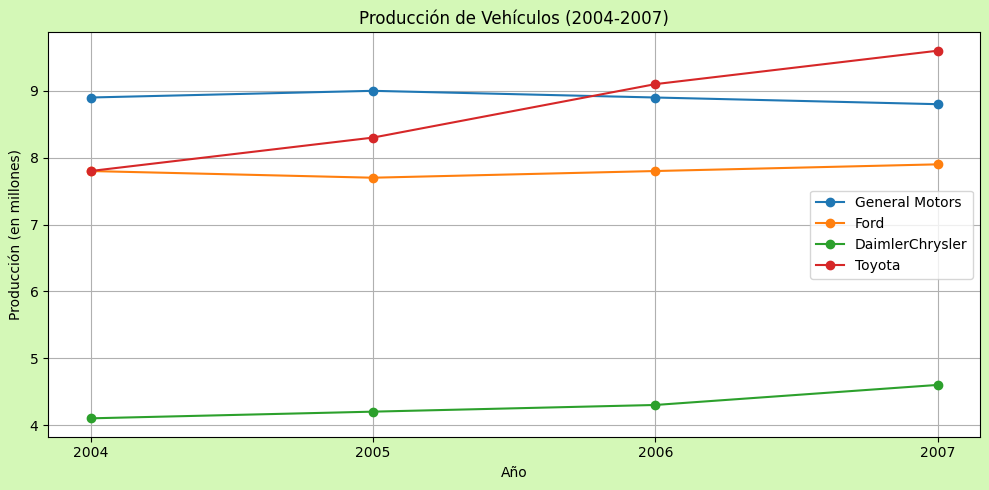

```
a: La gráfica de series de tiempo para los años 2004 a 2007 se ha generado arriba.
b: Según la gráfica, Toyota ha mostrado un aumento significativo en la producción y es el mayor productor en 2007.
c: La gráfica de sección transversal para el año 2007 mostraría la producción de vehículos de ese año para cada fabricante. Los datos son de sección transversal porque representan un corte en un punto en el tiempo, en este caso, el año 2007.
```

*a)* ¿Los datos son categóricos o cuantitativos?  
*b)* ¿Los datos son de series de tiempo o de corte transversal?  
*c)* ¿Cuántos medicamentos nuevos se aprobaron en 2003?  
*d)* ¿En qué año se aprobó el menor número de fármacos nuevos? ¿Cuántos fueron?  
*e)* Comente la tendencia en el número de medicamentos nuevos aprobados por la fda durante el periodo de ocho años.